# Homework Statistic

## I Gusti Ngurah Agung Hari Vijaya Kusuma / Batch 57

# Soal Pertama (10 poin)

Tunjukkan statistika deskriptif untuk variabel harga rumah (Column Name : SalePrice)!

Ceritakan kepada tim bisnis apa makna dari nilai nilai tersebut!

Ekspektasi output :

- ukuran pemusatan (4 poin)
- ukuran penyebaran (4 poin)
- Interpretasi (2 poin)

```python
import pandas as pd
import matplotlib.pyplot as plt
import seaborn as sns

agung = pd.read_csv(r'Dataset_Homework_1-4\train.csv')
agung.describe()
```

|  | Id | MSSubClass | LotFrontage | LotArea | OverallQual | OverallCond | YearBuilt | YearRemodAdd | MasVnrArea | BsmtFinSF1 | ... | WoodDeckSF | OpenPorchSF | EnclosedPorch | 3SsnPorch | ScreenPorch | PoolArea | MiscVal | MoSold | YrSold | SalePrice |
| --- | --- | --- | --- | --- | --- | --- | --- | --- | --- | --- | --- | --- | --- | --- | --- | --- | --- | --- | --- | --- | --- |
| count | 1460.000000 | 1460.000000 | 1201.000000 | 1460.000000 | 1460.000000 | 1460.000000 | 1460.000000 | 1460.000000 | 1452.000000 | 1460.000000 | ... | 1460.000000 | 1460.000000 | 1460.000000 | 1460.000000 | 1460.000000 | 1460.000000 | 1460.000000 | 1460.000000 | 1460.000000 | 1460.000000 |
| mean | 730.500000 | 56.897260 | 70.049958 | 10516.828082 | 6.099315 | 5.575342 | 1971.267808 | 1984.865753 | 103.685262 | 443.639726 | ... | 94.244521 | 46.660274 | 21.954110 | 3.409589 | 15.060959 | 2.758904 | 43.489041 | 6.321918 | 2007.815753 | 180921.195890 |
| std | 421.610009 | 42.300571 | 24.284752 | 9981.264932 | 1.382997 | 1.112799 | 30.202904 | 20.645407 | 181.066207 | 456.098091 | ... | 125.338794 | 66.256028 | 61.119149 | 29.317331 | 55.757415 | 40.177307 | 496.123024 | 2.703626 | 1.328095 | 79442.502883 |
| min | 1.000000 | 20.000000 | 21.000000 | 1300.000000 | 1.000000 | 1.000000 | 1872.000000 | 1950.000000 | 0.000000 | 0.000000 | ... | 0.000000 | 0.000000 | 0.000000 | 0.000000 | 0.000000 | 0.000000 | 0.000000 | 1.000000 | 2006.000000 | 34900.000000 |
| 25% | 365.750000 | 20.000000 | 59.000000 | 7553.500000 | 5.000000 | 5.000000 | 1954.000000 | 1967.000000 | 0.000000 | 0.000000 | ... | 0.000000 | 0.000000 | 0.000000 | 0.000000 | 0.000000 | 0.000000 | 0.000000 | 5.000000 | 2007.000000 | 129975.000000 |
| 50% | 730.500000 | 50.000000 | 69.000000 | 9478.500000 | 6.000000 | 5.000000 | 1973.000000 | 1994.000000 | 0.000000 | 383.500000 | ... | 0.000000 | 25.000000 | 0.000000 | 0.000000 | 0.000000 | 0.000000 | 0.000000 | 6.000000 | 2008.000000 | 163000.000000 |
| 75% | 1095.250000 | 70.000000 | 80.000000 | 11601.500000 | 7.000000 | 6.000000 | 2000.000000 | 2004.000000 | 166.000000 | 712.250000 | ... | 168.000000 | 68.000000 | 0.000000 | 0.000000 | 0.000000 | 0.000000 | 0.000000 | 8.000000 | 2009.000000 | 214000.000000 |
| max | 1460.000000 | 190.000000 | 313.000000 | 215245.000000 | 10.000000 | 9.000000 | 2010.000000 | 2010.000000 | 1600.000000 | 5644.000000 | ... | 857.000000 | 547.000000 | 552.000000 | 508.000000 | 480.000000 | 738.000000 | 15500.000000 | 12.000000 | 2010.000000 | 755000.000000 |

8 rows × 38 columns

```python
agung['SalePrice'].describe()
```

```
count      1460.000000
mean     180921.195890
std       79442.502883
min       34900.000000
25%      129975.000000
50%      163000.000000
75%      214000.000000
max      755000.000000
Name: SalePrice, dtype: float64
```

```python
nilai_range = agung['SalePrice'].max() - agung['SalePrice'].min()
print(f"Range of SalePrice: {nilai_range}")
nilai_variance = agung['SalePrice'].var()
print(f"Variance of SalePrice: {nilai_variance}")
```

```
Range of SalePrice: 720100
Variance of SalePrice: 6311111264.297448
```

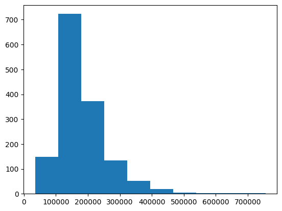

```python
plt.hist(agung['SalePrice'])
plt.show()
```

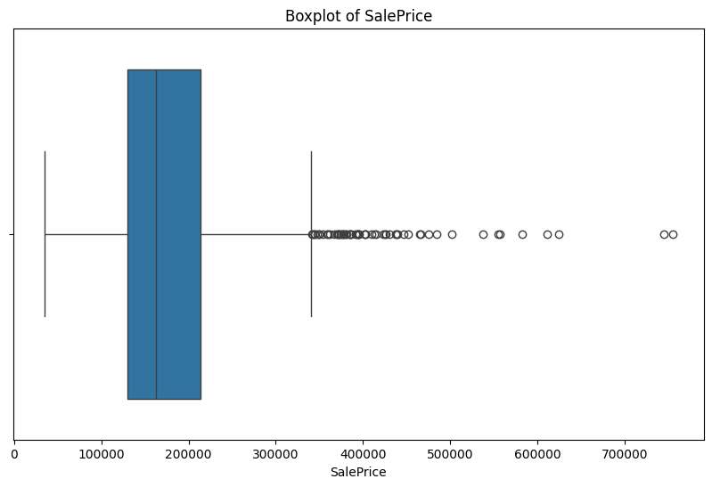

```python
#plot interquartile range
plt.figure(figsize=(10, 6))
sns.boxplot(x=agung['SalePrice'])
plt.title('Boxplot of SalePrice')
plt.xlabel('SalePrice')
plt.show()
```

```python
inter_quartile_range = agung['SalePrice'].quantile(0.75) - agung['SalePrice'].quantile(0.25)
print(f"Interquartile Range of SalePrice: {inter_quartile_range}")

batas_atas = agung['SalePrice'].quantile(0.75) + 1.5 * inter_quartile_range
batas_bawah = agung['SalePrice'].quantile(0.25) - 1.5 * inter_quartile_range
print(f"Upper Bound: {batas_atas}")
print(f"Lower Bound: {batas_bawah}")
```

```
Interquartile Range of SalePrice: 84025.0
Upper Bound: 340037.5
Lower Bound: 3937.5
```

### `Interpretasi`

- Terdapat **1.460 data** pada kolom SalePrice, yang berarti **tidak ada missing value**.
- Nilai **mean** adalah **$180,921.20** dan **median** adalah **$163,000.00**, menunjukkan bahwa distribusi data **tidak simetris**.
- Karena **mean lebih besar dari median**, maka distribusi data bersifat **positively skewed** (miring ke kanan).
- Distribusi harga rumah tidak simetris, dengan nilai rata-rata yang tertarik ke atas akibat keberadaan rumah-rumah dengan harga sangat tinggi (**outlier**).
- Dalam kondisi seperti ini, **median lebih representatif** sebagai ukuran pemusatan dibandingkan mean karena lebih tahan terhadap outlier.
- **Harga terendah** adalah **$34,900.00** dan **harga tertinggi** adalah **$755,000.00**, menghasilkan **range sebesar $720,100.00**.
- **Standar deviasi** sebesar **$79,442.50** menunjukkan bahwa **harga rumah sangat bervariasi** dari nilai rata-rata.
- **Interquartile Range (IQR)** adalah **$84,025.00**, yaitu selisih antara **kuartil ketiga ($214,000.00)** dan **kuartil pertama ($129,975.00)**.
  - dengan kuartil kita tahu bahwa **50% rumah** memiliki harga **berada di antara $129,975.00 dan $214,000.00**.
  - IQR menunjukkan **sebaran harga rumah di tengah populasi**, tanpa terpengaruh oleh nilai ekstrem (outlier).
- Berdasarkan metode IQR, sebuah harga rumah dianggap sebagai **outlier** apabila:
  - Di atas **$340,037.50** *(upper bound)*
  - Di bawah **$3,937.50** *(lower bound)*
- Dari hasil boxplot:
  - Terdapat **banyak rumah dengan harga di atas upper bound**, menandakan adanya **outlier mahal**.
  - **Tidak ada rumah** dengan harga di bawah lower bound, karena harga rumah termurah adalah **$34,900.00**, jauh di atas batas bawah tersebut.

### `Untuk Tim Bisnis :`

### Berdasarkan analisis terhadap data harga rumah (SalePrice), saya menemukan beberapa hal penting yang perlu menjadi perhatian:

1. Seluruh data harga rumah **lengkap tanpa nilai yang hilang** (missing value), sehingga dapat digunakan sepenuhnya untuk analisis dan pengambilan keputusan.
2. Distribusi harga rumah **tidak merata**. Rata-rata harga rumah saat ini adalah sekitar **$180,921**, namun mayoritas rumah berada di kisaran **$163,000**. Ini menunjukkan bahwa ada sejumlah rumah dengan harga sangat tinggi yang **mendorong rata-rata naik**, meskipun sebagian besar rumah berada di bawah angka tersebut.
3. Hal ini mengindikasikan bahwa harga rumah terdistribusi **miring ke kanan (positively skewed)**. Oleh karena itu, **median (Q2)** lebih tepat digunakan untuk merepresentasikan harga mayoritas rumah di pasar dibandingkan rata-rata.
4. Saya juga menemukan bahwa harga rumah **sangat bervariasi**, dengan harga terendah sebesar **$34,900** dan harga tertinggi mencapai **$755,000**. Rentang harga ini menunjukkan adanya **perbedaan yang signifikan dalam segmen pasar**.
5. Secara statistik, **50% rumah** berada dalam rentang harga **$129,975 hingga $214,000**. Rentang ini dapat dianggap sebagai **segmen pasar utama atau harga tipikal** bagi konsumen pada umumnya.
6. Berdasarkan metode IQR, rumah yang dijual dengan harga di atas **$340,037** termasuk dalam kategori **outlier mahal**. Dan benar saja, dari visualisasi boxplot, ditemukan banyak rumah dalam kategori ini.
7. Tidak ditemukan rumah dengan harga di bawah ambang batas bawah (**$3,937**), sehingga outlier hanya terjadi di sisi harga yang **sangat tinggi**.

### `Implikasi Bisnis`

1. **Tim penjualan dan pemasaran** sebaiknya berfokus pada rentang harga **$129,975 – $214,000**, karena inilah **segmen utama pasar** yang mencerminkan mayoritas pembeli.
2. Rumah dengan harga di atas **$340,000** mungkin memerlukan **strategi pemasaran khusus**, karena termasuk dalam kategori **high end** yang tidak merepresentasikan pasar umum.
3. Dalam pelaporan, forecasting, atau evaluasi performa harga rumah, **disarankan untuk menggunakan median** sebagai ukuran utama, agar tidak bias akibat keberadaan rumah-rumah dengan harga ekstrem yang tergolong outlier.

# Soal Kedua (25 poin)

Tunjukkan statistika deskriptif untuk variabel harga rumah (Column Name : SalePrice) setiap tahunnya (Column Name : YrSold)!

Secara deskriptif jelaskan apakah ada perbedaan setiap tahunnya atau tidak?

Ekspektasi output:

- ukuran pemusatan (10 poin)
- ukuran penyebaran (10 poin)
- Interpretasi (5 poin)

```python
agung.groupby('YrSold')['SalePrice'].describe()
```

| YrSold | count | mean | std | min | 25% | 50% | 75% | max |
| --- | --- | --- | --- | --- | --- | --- | --- | --- |
| 2006 | 314.0 | 182549.458599 | 79426.838855 | 35311.0 | 131375.0 | 163995.0 | 218782.5 | 625000.0 |
| 2007 | 329.0 | 186063.151976 | 85768.171410 | 39300.0 | 129900.0 | 167000.0 | 219500.0 | 755000.0 |
| 2008 | 304.0 | 177360.838816 | 69735.610685 | 40000.0 | 131250.0 | 164000.0 | 207000.0 | 446261.0 |
| 2009 | 338.0 | 179432.103550 | 80879.237311 | 34900.0 | 125250.0 | 162000.0 | 212750.0 | 582933.0 |
| 2010 | 175.0 | 177393.674286 | 80451.280085 | 55000.0 | 128100.0 | 155000.0 | 213250.0 | 611657.0 |

```python
#interquartile range harga rumah per tahun
inter_quartile_range_per_year = agung.groupby('YrSold')['SalePrice'].apply(lambda x: x.quantile(0.75) - x.quantile(0.25))
print("Interquartile Range of SalePrice per Year:")
print(inter_quartile_range_per_year)
```

```
Interquartile Range of SalePrice per Year:
YrSold
2006    87407.5
2007    89600.0
2008    75750.0
2009    87500.0
2010    85150.0
Name: SalePrice, dtype: float64
```

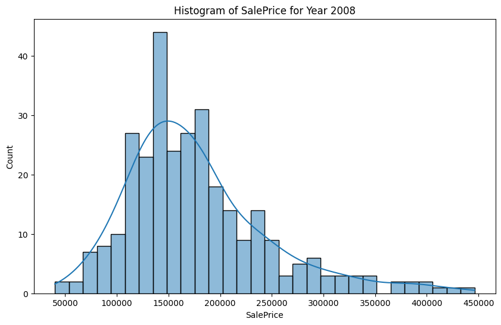

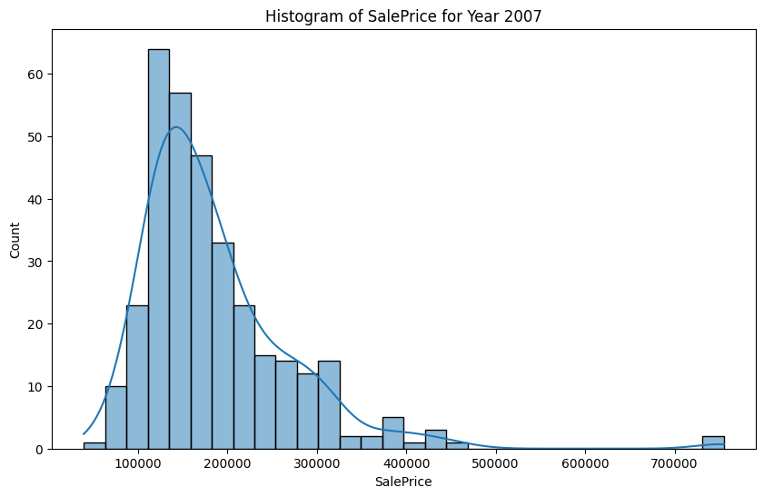

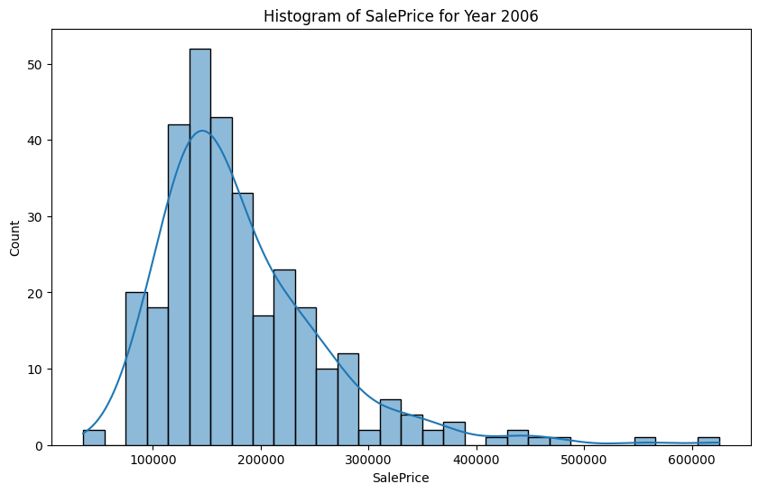

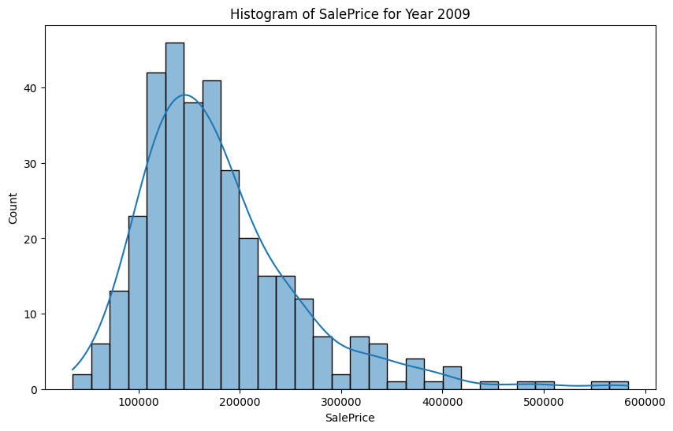

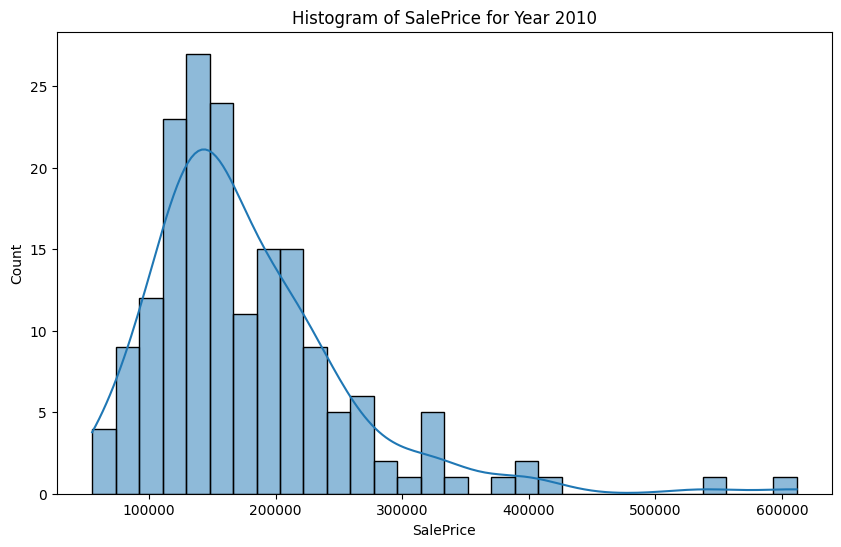

```python
#histogram untuk masing masing tahun
for year in agung['YrSold'].unique():
    plt.figure(figsize=(10, 6))
    sns.histplot(agung[agung['YrSold'] == year]['SalePrice'], bins=30, kde=True)
    plt.title(f'Histogram of SalePrice for Year {year}')
    plt.xlabel('SalePrice')
    plt.show()
```

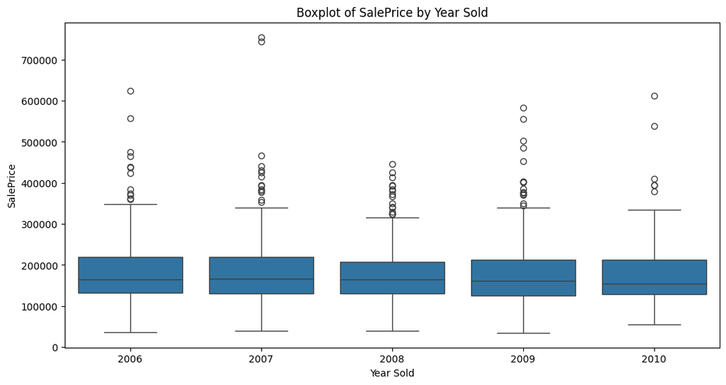

```python
#boxplotnya
plt.figure(figsize=(12, 6))
sns.boxplot(x='YrSold', y='SalePrice', data=agung)
plt.title('Boxplot of SalePrice by Year Sold')
plt.xlabel('Year Sold')
plt.ylabel('SalePrice')
plt.show()
```

```python
#mengecek upperbound dan lower bound per tahun
upper_bounds_per_year = agung.groupby('YrSold')['SalePrice'].apply(lambda x: x.quantile(0.75) + 1.5 * (x.quantile(0.75) - x.quantile(0.25)))
lower_bounds_per_year = agung.groupby('YrSold')['SalePrice'].apply(lambda x: x.quantile(0.25) - 1.5 * (x.quantile(0.75) - x.quantile(0.25)))
print("Upper Bounds per Year:")
print(upper_bounds_per_year)
print("Lower Bounds per Year:")
print(lower_bounds_per_year)
```

```
Upper Bounds per Year:
YrSold
2006    349893.75
2007    353900.00
2008    320625.00
2009    344000.00
2010    340975.00
Name: SalePrice, dtype: float64
Lower Bounds per Year:
YrSold
2006      263.75
2007    -4500.00
2008    17625.00
2009    -6000.00
2010      375.00
Name: SalePrice, dtype: float64
```

```python
agung.groupby('YrSold')['SalePrice'].describe()
```

| YrSold | count | mean | std | min | 25% | 50% | 75% | max |
| --- | --- | --- | --- | --- | --- | --- | --- | --- |
| 2006 | 314.0 | 182549.458599 | 79426.838855 | 35311.0 | 131375.0 | 163995.0 | 218782.5 | 625000.0 |
| 2007 | 329.0 | 186063.151976 | 85768.171410 | 39300.0 | 129900.0 | 167000.0 | 219500.0 | 755000.0 |
| 2008 | 304.0 | 177360.838816 | 69735.610685 | 40000.0 | 131250.0 | 164000.0 | 207000.0 | 446261.0 |
| 2009 | 338.0 | 179432.103550 | 80879.237311 | 34900.0 | 125250.0 | 162000.0 | 212750.0 | 582933.0 |
| 2010 | 175.0 | 177393.674286 | 80451.280085 | 55000.0 | 128100.0 | 155000.0 | 213250.0 | 611657.0 |

```python
agung.groupby('YrSold')['SalePrice'].agg(['count'])
```

| YrSold | count |
| --- | --- |
| 2006 | 314 |
| 2007 | 329 |
| 2008 | 304 |
| 2009 | 338 |
| 2010 | 175 |

```python
agung.groupby('YrSold')['SalePrice'].agg(mean = 'mean', median=lambda x: x.quantile(0.5))
```

| YrSold | mean | median |
| --- | --- | --- |
| 2006 | 182549.458599 | 163995.0 |
| 2007 | 186063.151976 | 167000.0 |
| 2008 | 177360.838816 | 164000.0 |
| 2009 | 179432.103550 | 162000.0 |
| 2010 | 177393.674286 | 155000.0 |

### `Interpretasi`

- Terdapat **314** rumah terjual pada tahun **2006**, **329** pada tahun **2007**, **304** pada tahun **2008**, **338** pada tahun **2009**, dan **175** pada tahun **2010**.
- Tahun **2009** menjadi tahun dengan jumlah **penjualan terbanyak** yaitu **338 unit**, sedangkan tahun **2010** memiliki **jumlah penjualan paling sedikit** yaitu **175 unit**.
- Rata-rata harga rumah tiap tahun:
  - **2006**: **$182,549.46**
  - **2007**: **$186,063.15**
  - **2008**: **$177,360.84**
  - **2009**: **$179,432.10**
  - **2010**: **$177,393.67**
- Median (Q2) harga rumah tiap tahun:
  - **2006**: **$163,995.00**
  - **2007**: **$167,000.00** ← *Tertinggi*
  - **2008**: **$164,000.00**
  - **2009**: **$162,000.00**
  - **2010**: **$155,000.00** ← *Terendah*
- **Rata-rata selalu lebih besar dari median**, menunjukkan bahwa distribusi harga rumah setiap tahun bersifat **positively skewed** (condong ke kanan).
- Distribusi yang tidak simetris ini mengindikasikan adanya **outlier mahal** yang menarik rata-rata ke atas.
- Oleh karena itu, **median lebih representatif** untuk menggambarkan harga mayoritas rumah di pasar.
- **Tahun 2007** menjadi tahun dengan median tertinggi, menggambarkan **kondisi pasar yang kuat dan aktif**, sementara **tahun 2010** menunjukkan **penurunan daya beli atau efek koreksi pasar**.

### Interquartile Range (IQR) per Tahun

- IQR adalah selisih antara kuartil ketiga (Q3) dan kuartil pertama (Q1"), menggambarkan sebaran harga rumah di tengah 50% populasi.
- Nilai IQR per tahun:
  - **2006**: **$87,407.50**
  - **2007**: **$89,600.00** ← *Tertinggi*
  - **2008**: **$75,750.00** ← *Terendah*
  - **2009**: **$87,500.00**
  - **2010**: **$85,150.00**
- **Tahun 2007** memiliki variasi harga terbesar dalam kelompok tengah pasar, sedangkan **tahun 2008** menunjukkan pasar yang lebih stabil dan homogen.
- **IQR yang tinggi** menggambarkan **keragaman segmen pasar** yang luas dan penting untuk strategi penetapan harga.
- Karena IQR tidak terpengaruh outlier, ini adalah ukuran yang **andal untuk memahami variasi harga normal**.

### Batas Atas dan Bawah (Outlier Threshold) per Tahun

- Batas atas (Upper Bound) harga rumah berdasarkan IQR:
  - **2006**: **$349,893.75**
  - **2007**: **$353,900.00** ← *Tertinggi*
  - **2008**: **$320,625.00** ← *Terendah*
  - **2009**: **$344,000.00**
  - **2010**: **$340,975.00**
- Rumah yang dijual di atas nilai tersebut dianggap **outlier mahal**, dan ini terlihat jelas pada **boxplot tiap tahun**.
- Tidak ditemukan rumah dengan harga di bawah batas bawah (lower bound) yang signifikan menunjukkan bahwa **outlier hanya terjadi pada sisi harga tinggi**.
- **Distribusi positively skewed setiap tahun** juga menguatkan temuan ini.
- Tahun **2007** memiliki **batas atas (upper bound) tertinggi** yaitu **$353,900.00**. Hal ini berarti:
  - Harga rumah pada tahun 2007 secara keseluruhan lebih tinggi dibandingkan tahun-tahun lainnya.
  - Untuk dianggap sebagai **outlier mahal di tahun 2007**, harga rumah harus lebih tinggi dari $353,900, sedangkan di tahun lain batas tersebut lebih rendah.
  - Ini mengindikasikan bahwa **tingkat harga yang dianggap “normal” oleh pasar saat itu lebih tinggi** daripada tahun-tahun lainnya.
- Temuan ini penting karena:
  - Bisa mencerminkan **optimisme pasar** atau **lonjakan permintaan properti** pada tahun tersebut.
  - Tahun 2007 bisa dianggap sebagai **puncak siklus pasar properti** dalam periode 2006–2010.

### Standar Deviasi per Tahun (kurang relevan mengingat outlier)

- Standar deviasi menunjukkan **seberapa besar variasi harga rumah dari rata-rata**.
- Nilai standar deviasi per tahun:
  - **2006**: **$79,427**
  - **2007**: **$85,768** ← *Tertinggi*
  - **2008**: **$69,736** ← *Terendah*
  - **2009**: **$80,879**
  - **2010**: **$80,451**
- **Tahun 2007** memiliki standar deviasi tertinggi, selaras dengan IQR dan batas atas tertinggi, menunjukkan **pasar paling beragam secara harga**.
- **Tahun 2008** menunjukkan **pasar yang paling stabil**, dengan variasi harga yang paling kecil.

### `Kesimpulan: Apakah Ada Perbedaan Setiap Tahunnya?`

Berdasarkan analisis statistik deskriptif, dapat disimpulkan bahwa **terdapat perbedaan harga rumah antar tahun**, baik dari segi **rata-rata, median, maupun penyebaran (IQR dan standar deviasi)**.

- **Tahun 2007** menonjol sebagai tahun dengan **harga rumah tertinggi secara median dan variasi harga paling besar**, menandakan kondisi pasar yang relatif kuat.
- **Tahun 2010** menjadi tahun dengan **median terendah dan jumlah penjualan paling sedikit**, mencerminkan kemungkinan penurunan daya beli atau kondisi pasar yang melemah.
- **IQR** juga menunjukkan **perbedaan pola sebaran harga tiap tahun**, dengan 2008 sebagai tahun paling stabil dan 2007 sebagai tahun paling bervariasi.
- Keberadaan outlier mahal yang konsisten setiap tahun, terutama di tahun 2007 dan 2008, menunjukkan **perbedaan dinamika pasar dan segmen highend** antar periode.

Dengan demikian, **secara deskriptif terdapat perbedaan karakteristik harga rumah setiap tahunnya**, baik dari sisi pemusatan (mean, median) maupun penyebarannya (std, IQR).

# Soal Ketiga (25 poin)

Bagaimana distribusi harga rumah tersebut. Gunakan histogram plot tidak terbatas hanya histogram saja. Jelaskan sebaiknya untuk analisa apakah lebih baik menggunakan mean atau menggunakan median? Beserta alasannya (Column Name : SalePrice)

Ceritakan analisa tersebut dengan sudut pandang statistika. Buatlah tim bisnis paham maksud dari grafik histogram tersebut.

Ekspektasi :

- Grafik Histogram (8 poin)
- Analisa (12 poin)
- Interpretasi (5 poin)

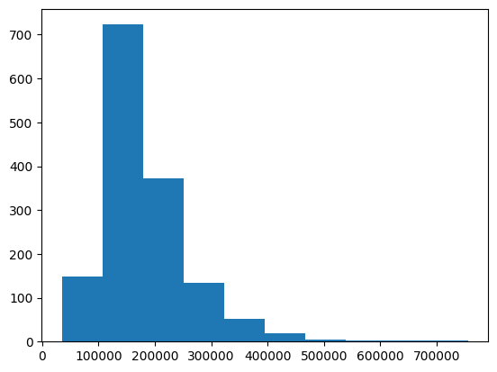

```python
plt.hist(agung['SalePrice'])
plt.show()
```

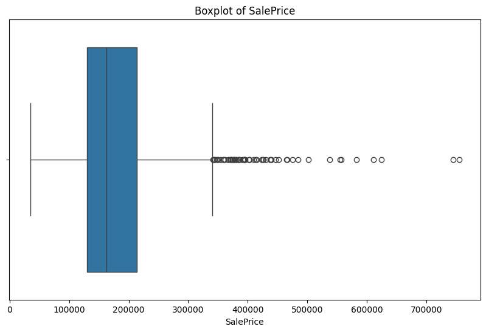

```python
plt.figure(figsize=(10, 6))
sns.boxplot(x=agung['SalePrice'])
plt.title('Boxplot of SalePrice')
plt.xlabel('SalePrice')
plt.show()
```

```python
agung['SalePrice'].describe()
```

```
count      1460.000000
mean     180921.195890
std       79442.502883
min       34900.000000
25%      129975.000000
50%      163000.000000
75%      214000.000000
max      755000.000000
Name: SalePrice, dtype: float64
```

### `Histogram Saleprice`

[figure not shown]

### `Analisis Statistik`

- Histogram menunjukkan bahwa **distribusi harga rumah tidak simetris** dan **mengumpul di sisi kiri** (harga rendah), sementara **ekor panjangnya ke kanan** (harga tinggi).
- Pola ini dikenal sebagai **positively skewed distribution** artinya, banyak rumah berada di kisaran harga rendah hingga menengah, tetapi ada **beberapa rumah dengan harga sangat tinggi** (outlier) yang menarik ekor distribusi ke kanan.
- Ini konsisten dengan nilai-nilai deskriptif sebelumnya:
  - **Mean**: $180,921.20
  - **Median**: $163,000.00
  - **Standard Deviation**: $79,442.50
  - **IQR**: $84,025.00
- Perbedaan antara mean dan median sebesar ~$17,000 menunjukkan bahwa **mean terdorong oleh harga-harga ekstrem**, sehingga **tidak mewakili harga mayoritas rumah**. Oleh karena itu penggunaan **nilai median** menjadi nilai yang **lebih tepat** dalam merepresenstasikan pasar

### `Interpretasi`

- Berdasarkan bentuk distribusi, **median adalah ukuran pemusatan yang lebih tepat** dibandingkan mean.
  - Mengapa? Karena median **tidak terpengaruh oleh outlier** dan merepresentasikan **harga tengah** dari seluruh rumah di pasar.
  - Dalam konteks ini, **50% rumah dijual antara $129,975 dan $214,000**, yang merupakan rentang harga yang umum dan wajar.
- Jika kita hanya menggunakan **mean**, tim bisnis bisa salah menafsirkan bahwa mayoritas rumah dijual mendekati $180,000 padahal tidak.
- Grafik histogram mendukung temuan ini karena menunjukkan **konsentrasi massa data di bawah $200,000**, dan hanya sebagian kecil yang menyebar ke area harga tinggi.

### Kesimpulan

- Distribusi `SalePrice` bersifat **positively skewed**.
- **Median ($163,000)** lebih representatif dibanding **mean ($180,921)** untuk menyimpulkan harga rumah secara umum.
- **Rekomendasi**: gunakan median sebagai acuan untuk penetapan harga, evaluasi performa, dan pengambilan keputusan strategis terkait harga rumah.

## Soal Keempat (30 poin)

Karena ada pernyataan bahwa setiap tahunnya harga rumah itu pasti naik. (tahun terjual : YrSold, harga rumah : SalePrice) Silahkan teman-teman buktikan dengan data yang ada menggunakan ilmu statistika? (Tidak terbatas pada pengujian apapun)

Ekspektasi :

- Penentuan hipotesis (5 poin)
- Pengujian yang digunakan (5 poin)
- Hasil pengujian hipotesis (10 poin)
- Kesimpulan dan interpretasi (10 poin)

```python
agung.groupby('YrSold')['SalePrice'].describe()
```

| YrSold | count | mean | std | min | 25% | 50% | 75% | max |
| --- | --- | --- | --- | --- | --- | --- | --- | --- |
| 2006 | 314.0 | 182549.458599 | 79426.838855 | 35311.0 | 131375.0 | 163995.0 | 218782.5 | 625000.0 |
| 2007 | 329.0 | 186063.151976 | 85768.171410 | 39300.0 | 129900.0 | 167000.0 | 219500.0 | 755000.0 |
| 2008 | 304.0 | 177360.838816 | 69735.610685 | 40000.0 | 131250.0 | 164000.0 | 207000.0 | 446261.0 |
| 2009 | 338.0 | 179432.103550 | 80879.237311 | 34900.0 | 125250.0 | 162000.0 | 212750.0 | 582933.0 |
| 2010 | 175.0 | 177393.674286 | 80451.280085 | 55000.0 | 128100.0 | 155000.0 | 213250.0 | 611657.0 |

```python
from scipy.stats import kruskal

tahun_2006 = agung[agung['YrSold'] == 2006]['SalePrice']
tahun_2007 = agung[agung['YrSold'] == 2007]['SalePrice']
tahun_2008 = agung[agung['YrSold'] == 2008]['SalePrice']
tahun_2009 = agung[agung['YrSold'] == 2009]['SalePrice']
tahun_2010 = agung[agung['YrSold'] == 2010]['SalePrice']

print(tahun_2007.describe())
```

```
count       329.000000
mean     186063.151976
std       85768.171410
min       39300.000000
25%      129900.000000
50%      167000.000000
75%      219500.000000
max      755000.000000
Name: SalePrice, dtype: float64
```

```python
kruskal_result = kruskal(tahun_2006, tahun_2007, tahun_2008, tahun_2009, tahun_2010)
```

```python
agung.groupby('YrSold')['SalePrice'].agg(median=lambda x: x.quantile(0.5))
```

| YrSold | median |
| --- | --- |
| 2006 | 163995.0 |
| 2007 | 167000.0 |
| 2008 | 164000.0 |
| 2009 | 162000.0 |
| 2010 | 155000.0 |

```python
kruskal_result
```

```
KruskalResult(statistic=np.float64(1.645903303251481), pvalue=np.float64(0.800519267418441))
```

```python
p_value = kruskal_result.pvalue
alpha = 0.05
print('P-Value :',p_value)

if p_value >= alpha:
    print('Tidak cukup bukti menyatakan bahwa harga rumah setiap tahunnya berbeda')
else:
    print('Cukup bukti menyatakan (Tolak H0) bahwa harga rumah setiap tahunnya berbeda')
```

```
P-Value : 0.800519267418441
Tidak cukup bukti menyatakan bahwa harga rumah setiap tahunnya berbeda
```

### `Penentuan Hipotesis`

Pada interpretasi di nomer 2 saya menemukan bahwa:

- **Rata-rata selalu lebih besar dari median**, menunjukkan bahwa distribusi harga rumah setiap tahun bersifat **positively skewed** (condong ke kanan).
- Distribusi yang tidak simetris ini mengindikasikan adanya **outlier mahal** yang menarik rata-rata ke atas.
- Oleh karena itu, **median lebih representatif** untuk menggambarkan harga mayoritas rumah di pasar.

Dan terdapat pernyataan bahwa setiap tahunnya harga rumah itu pasti naik. maka bisa kita tentukan hipotesis 0 dan 1 :

- Hipotesis Nol **(H₀): harga rumah tidak mengalami peningkatan signifikan setiap tahunnya.**
- Hipotesis Alternatif **(H₁): harga rumah mengalami peningkatan signifikan setiap tahunnya.**

### `Pengujian yang digunakan`

Berdasarkan dua poin diatas untuk menarik kesimpulan maka nilai median tiap tahun akan digunakan sebagai acuan terhadap peningkatan harga rumah, sehingga pengujian yang akan dilakukan adalah menggunakan uji statistik **Kruskal-Wallis**. Uji statistik ini diambil karena dari interpretasi yang saya lakukan pada nomer 2 saya menemukan **bahwa outlier menyebabkan nilai mean (rata -rata ) menjadi ketarik ke atas** dan tidak dapat merepresentasikan data, **oleh karena itu saya akan menggunakan median sebagai representasi harga rumah** per tiap tahunnya sehingga kita bisa menguji apakah harga rumah memiliki peningkatan atau tidak. Dimana kruskal wallis ini sesuai dengan hasil analisa yang saya dapatkan dimana :

- Kolom SalePrice tidak normal (positively skewed).
- Terdapat banyak outlier mahal.
- Kalau menggunakan ANOVA bisa misleading karena rata-rata tertarik oleh outlier.
- Maka lebih aman gunakan Kruskal Wallis, karena pengujian ini tidak peduli distribusinya bagaimana cukup urutkan dan bandingkan peringkatnya saja.

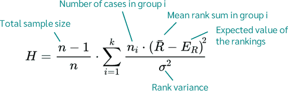

gambar diatas merupakan formula dari uji statistik kruskal wallis yang akan digunakan untuk mendapatkan kesimpulan dari hipotesis, namun tidak akan saya jelaskan karena saya mager dan kita cukup panggil menggunakan Scipy kruskal(df_tahun1,df_tahun2 ...).

cara kerjanya kurang lebih:

- Gabungkan semua data dari berbagai kelompok (dalam kasus ini: SalePrice dari setiap tahun).
- Urutkan semua data dari yang terkecil ke terbesar, lalu beri peringkat (rank).
- Hitung rata-rata peringkat untuk tiap kelompok.

### `Hasil Uji`

Hasil pengujian:

**KruskalResult(statistic=np.float64(1.645903303251481), pvalue=np.float64(0.800519267418441))**

### **Karena p-value > 0.05, maka kita tidak punya cukup bukti untuk menolak H₀.**

### `Kesimpulan dan interpretasi`

Berdasarkan hasil uji Kruskal-Wallis, tidak terdapat perbedaan signifikan antara harga rumah pada tahun 2006 hingga 2010.

Dengan demikian, klaim bahwa harga rumah selalu naik setiap tahun tidak didukung oleh data statistik. Fluktuasi harga dari tahun ke tahun lebih disebabkan oleh variasi acak atau faktor eksternal lainnya, bukan karena tren kenaikan yang konsisten.

# Soal Kelima(10 Poin)

Kasus yang akan digunakan adalah membuka akun deposit untuk nasabah bank. Pada kesempatan kali ini data scientist diminta tolong untuk menganalisa hasil ab-testing suatu perusahaan bank. Apakah jumlah campaign mampu meningkatkan keinginan user untuk membuka akun deposit atau tidak?

Data yang digunakan berasal dari folder bank.zip file yang digunakan adalah bank-full.csv

1. Untuk variabel jumlah campaign bisa dicek untuk kolom campaign
2. untuk variabel apakah akhirnya user membuka akun atau tidak bisa menggunakan variabel y

## Pemahaman konsep A/B Testing (5 poin)

- Apa nama experimentnya?
- Definisikan Hipotesis
- Siapa participant-nya?
- Variabel yang akan diuji apa?
- Metrics apa yang akan digunakan?
- Berapa sample size dan durasi experiment?

## Pengujian Hipotesis (5 poin)

- Penentuan hipotesis
- Pengujian yang digunakan
- Deteksi asumsi beserta cara penanganannya
- Hasil pengujian hipotesis
- Kesimpulan dan interpretasi

```python
gemeter = pd.read_csv(r'Dataset_Homework_5\bank-full.csv', delimiter=';')
gemeter.head()
```

|  | age | job | marital | education | default | balance | housing | loan | contact | day | month | duration | campaign | pdays | previous | poutcome | y |
| --- | --- | --- | --- | --- | --- | --- | --- | --- | --- | --- | --- | --- | --- | --- | --- | --- | --- |
| 0 | 58 | management | married | tertiary | no | 2143 | yes | no | unknown | 5 | may | 261 | 1 | -1 | 0 | unknown | no |
| 1 | 44 | technician | single | secondary | no | 29 | yes | no | unknown | 5 | may | 151 | 1 | -1 | 0 | unknown | no |
| 2 | 33 | entrepreneur | married | secondary | no | 2 | yes | yes | unknown | 5 | may | 76 | 1 | -1 | 0 | unknown | no |
| 3 | 47 | blue-collar | married | unknown | no | 1506 | yes | no | unknown | 5 | may | 92 | 1 | -1 | 0 | unknown | no |
| 4 | 33 | unknown | single | unknown | no | 1 | no | no | unknown | 5 | may | 198 | 1 | -1 | 0 | unknown | no |

```python
gemeter.describe()
```

|  | age | balance | day | duration | campaign | pdays | previous |
| --- | --- | --- | --- | --- | --- | --- | --- |
| count | 45211.000000 | 45211.000000 | 45211.000000 | 45211.000000 | 45211.000000 | 45211.000000 | 45211.000000 |
| mean | 40.936210 | 1362.272058 | 15.806419 | 258.163080 | 2.763841 | 40.197828 | 0.580323 |
| std | 10.618762 | 3044.765829 | 8.322476 | 257.527812 | 3.098021 | 100.128746 | 2.303441 |
| min | 18.000000 | -8019.000000 | 1.000000 | 0.000000 | 1.000000 | -1.000000 | 0.000000 |
| 25% | 33.000000 | 72.000000 | 8.000000 | 103.000000 | 1.000000 | -1.000000 | 0.000000 |
| 50% | 39.000000 | 448.000000 | 16.000000 | 180.000000 | 2.000000 | -1.000000 | 0.000000 |
| 75% | 48.000000 | 1428.000000 | 21.000000 | 319.000000 | 3.000000 | -1.000000 | 0.000000 |
| max | 95.000000 | 102127.000000 | 31.000000 | 4918.000000 | 63.000000 | 871.000000 | 275.000000 |

```python
gemeter.info()
```

```
<class 'pandas.core.frame.DataFrame'>
RangeIndex: 45211 entries, 0 to 45210
Data columns (total 17 columns):
 #   Column     Non-Null Count  Dtype
---  ------     --------------  -----
 0   age        45211 non-null  int64
 1   job        45211 non-null  object
 2   marital    45211 non-null  object
 3   education  45211 non-null  object
 4   default    45211 non-null  object
 5   balance    45211 non-null  int64
 6   housing    45211 non-null  object
 7   loan       45211 non-null  object
 8   contact    45211 non-null  object
 9   day        45211 non-null  int64
 10  month      45211 non-null  object
 11  duration   45211 non-null  int64
 12  campaign   45211 non-null  int64
 13  pdays      45211 non-null  int64
 14  previous   45211 non-null  int64
 15  poutcome   45211 non-null  object
 16  y          45211 non-null  object
dtypes: int64(7), object(10)
memory usage: 5.9+ MB
```

```python
gemeter['campaign'].max()
```

```
np.int64(63)
```

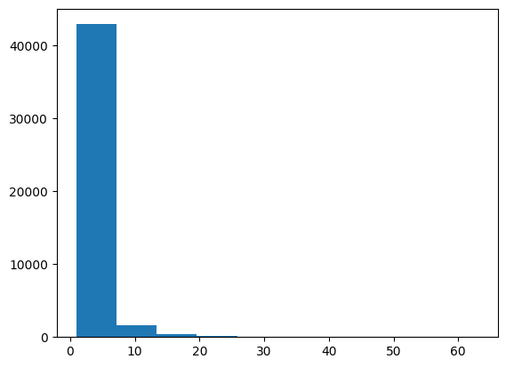

```python
plt.hist(gemeter['campaign'])
plt.show()
```

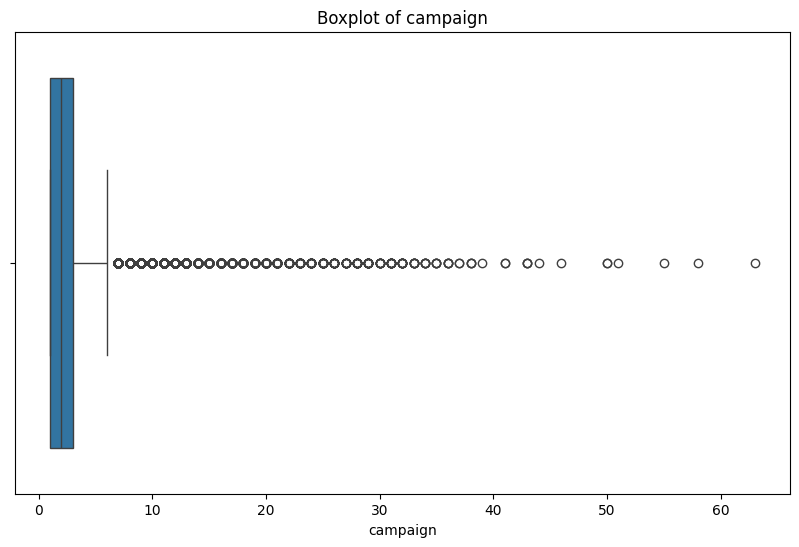

```python
#plot interquartile range
plt.figure(figsize=(10, 6))
sns.boxplot(x=gemeter['campaign'])
plt.title('Boxplot of campaign')
plt.xlabel('campaign')
plt.show()
```

```python
iqr_mantap = gemeter['campaign'].quantile(0.75) - gemeter['campaign'].quantile(0.25)
print(f"Interquartile Range of campaign: {iqr_mantap}")

batas_atas = gemeter['campaign'].quantile(0.75) + 1.5 * iqr_mantap
batas_bawah = gemeter['campaign'].quantile(0.25) - 1.5 * iqr_mantap
print(f"Upper Bound: {batas_atas}")
print(f"Lower Bound: {batas_bawah}")
```

```
Interquartile Range of campaign: 2.0
Upper Bound: 6.0
Lower Bound: -2.0
```

```python
gemeter['campaign'].count()
```

```
np.int64(45211)
```

```python
gemeter['campaign'].count()
e = 0.05
#menghitung slovin untuk menentukan ukuran sampel
n = gemeter['campaign'].count()
n_slovin = n / (1 + n * e**2)
print(n_slovin)
```

```
396.4920742803271
```

```python
gemeter.groupby('y')['campaign'].describe()
```

| y | count | mean | std | min | 25% | 50% | 75% | max |
| --- | --- | --- | --- | --- | --- | --- | --- | --- |
| no | 39922.0 | 2.846350 | 3.212767 | 1.0 | 1.0 | 2.0 | 3.0 | 63.0 |
| yes | 5289.0 | 2.141047 | 1.921826 | 1.0 | 1.0 | 2.0 | 3.0 | 32.0 |

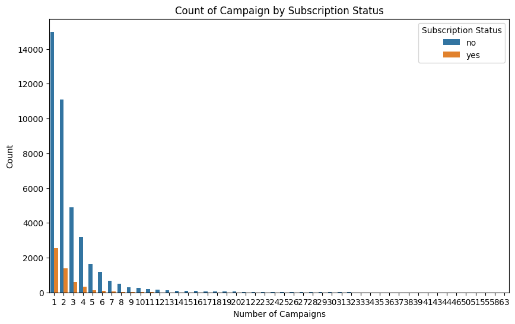

```python
#plot untuk memeriksa apakah jumlah campaign mempengaruhi yes atau no, melihat mana yang lebih banyak
plt.figure(figsize=(10, 6))
sns.countplot(x='campaign', hue='y', data=gemeter)
plt.title('Count of Campaign by Subscription Status')
plt.xlabel('Number of Campaigns')
plt.ylabel('Count')
plt.legend(title='Subscription Status')
plt.show()
```

```python
from scipy.stats import mannwhitneyu

yes = gemeter[gemeter['y'] == 'yes']['campaign']
no = gemeter[gemeter['y'] == 'no']['campaign']

stat, p_value = mannwhitneyu(yes, no, alternative='two-sided')

(stat, p_value)
```

```
(np.float64(90300543.5), np.float64(1.9484904873905108e-71))
```

```python
alpha = 0.05
print('P-Value :',p_value)

if p_value >= alpha:
    print('Tidak cukup bukti jumlah campaign mampu membedakan user untuk membuka akun atau tidak')
else:
    print('cukup bukti jumlah campaign mampu membedakan user untuk membuka akun atau tidak')
```

```
P-Value : 1.9484904873905108e-71
cukup bukti jumlah campaign mampu membedakan user untuk membuka akun atau tidak
```

### `Pemahaman Konsep A/B Testing`

#### `Apa nama experiment-nya?`

**Campaign Effectiveness Experiment**  
Eksperimen ini bertujuan untuk menguji apakah **jumlah campaign** (frekuensi kontak marketing ke nasabah) mampu meningkatkan keinginan nasabah untuk membuka akun **deposito**.

#### `Definisikan Hipotesis`

- Hipotesis Nol **(H₀): jumlah campaign nasabah yang membuka akun **sama** dengan yang tidak membuka akun .**
- Hipotesis Alternatif **(H₁): jumlah campaign nasabah yang membuka akun **berbeda** dengan yang tidak membuka akun.**

#### `Siapa participant-nya?`

Nasabah bank yang dihubungi oleh marketing dan memiliki data lengkap

#### `Variabel yang akan diuji`

- jumlah campaign

#### `Metrics yang digunakan`

- Conversion rate dipilih sebagai macroconversion metric karena merupakan tujuan utama eksperimen: ingin tahu apakah user jadi membuka akun setelah dikirimi campaign.

#### `Berapa sample size dan durasi experiment?`

- **sample:** 396 sampel dengan error 0.05 atau 5% karena sering digunakan (mengacu pada modul LMS)
- **Durasi:** 12 jam

[figure not shown]

### `Pengujian Hipotesis`

#### `Penentuan Hipotesis`

- Hipotesis Nol **(H₀): jumlah campaign nasabah yang membuka akun **sama** dengan yang tidak membuka akun .**
- Hipotesis Alternatif **(H₁): jumlah campaign nasabah yang membuka akun **berbeda** dengan yang tidak membuka akun.**

#### `Pengujian yang Digunakan`

Dari hasil analisa didapatkan nilai mean lebih tinggi ketimbang nilai q2 maka:

- Kolom campaign memiliki distribusi yang skewed (condong kanan) yang dapat dilihat pada plot.
- Banyak outlier pada jumlah campaign.
- Mean tidak representatif, sehingga lebih baik menggunakan metode non parametrik

Uji Mann Whitney U Test, yaitu uji non parametrik dua sampel independen yang tidak mengasumsikan distribusi normal. cara kerjanya mirip seperti kruskal wallis yang menggunakan peringkat, ini rumusnya

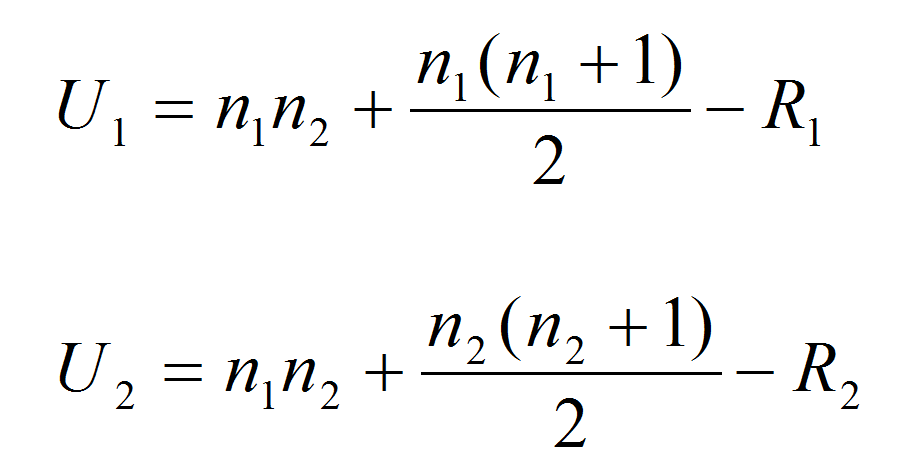

Mann-Whitney U Test menghitung dua nilai statistik yang disebut:

U₁ = jumlah kemenangan grup 1 terhadap grup 2

U₂ = jumlah kemenangan grup 2 terhadap grup 1

Kemenangan = saat data dari satu grup memiliki peringkat lebih tinggi dari grup lain.

`contoh`

Kita punya dua grup:

Grup A (y = yes): [3, 5, 6]

Grup B (y = no): [2, 4, 8]

Gabungkan dan urutkan semua nilai: 2 (B), 3 (A), 4 (B), 5 (A), 6 (A), 8 (B)

Lalu hitung berapa kali setiap elemen di grup A menang melawan B:

3 > 2 → menang

5 > 2, 4 → menang 2x

6 > 2, 4 → menang 2x

Total menang = U₁ = 5 Sebaliknya, U₂ dihitung dari sudut pandang grup B.

Setelah dapat U₁ dan U₂, kita ambil nilai yang lebih kecil untuk dibandingkan ke tabel distribusi U (kalau hitung manual), atau langsung hitung p-value (kalau pakai scipy.stats.mannwhitneyu cara gacor dan simpel).

#### `Deteksi Asumsi dan Penanganannya`

- Data berskala ordinal/interval campaign adalah data numerik diskrit.
- Dua kelompok independen yes dan no.
- Data tidak terdistribusi normal maka tidak cocok untuk uji t.

Penanganan:

- Digunakan **uji non-parametrik** Mann Whitney U Test, yang **tidak mengasumsikan normalitas** dan **tahan terhadap outlier**

#### `Hasil Pengujian Hipotesis`

didapatkan hasil (np.float64(90300543.5), np.float64(1.9484904873905108e-71)).

### **Karena p-value < 0.05, maka kita punya cukup bukti untuk menerima H1.**

#### `Kesimpulan dan Interpretasi`

Dengan demikian, hipotesis nol (H₀) yang menyatakan bahwa jumlah campaign nasabah yang membuka akun sama dengan yang tidak membuka akun **ditolak**, dan kita **menerima hipotesis alternatif (H₁)**, yaitu bahwa jumlah campaign nasabah yang membuka akun berbeda dengan yang tidak membuka akun.

Artinya, jumlah campaign yang dilakukan memang memiliki perbedaan yang signifikan antara kedua kelompok nasabah tersebut, sehingga dapat diasumsikan bahwa campaign yang diberikan dapat berdampak terhadap keputusan nasabah dalam membuka akun.

Dengan meninjau bahwa nilai median menjadi nilai representatif dari jumlah campaign mengingat bahwa besarnya nilai outlier yang ada dalam data. maka didapatkan bahwa Walaupun nilai median campaign kedua kelompok sama (yaitu 2), data menunjukkan bahwa nasabah yang tidak membuka akun (y = no) memiliki rata-rata campaign yang lebih tinggi (mean = 2.85) dan sebaran yang lebih luas, dengan outlier mencapai 63 campaign. Sementara kelompok yang membuka akun (y = yes) memiliki rata-rata lebih rendah (mean = 2.14) dan sebaran lebih sempit.

Hal ini menunjukkan bahwa campaign berlebihan tidak selalu efektif, bahkan bisa berdampak negatif. Dengan kata lain, jumlah campaign yang terlalu banyak justru berhubungan dengan penolakan membuka akun.